# Risk Factor Analysis

## Outcome Variable

**Outcome Variable:** sstunted

## Predictor Variables

**Intervention Variable:** enstunt

**Adjustment Set:**

- arm
- sex
- W_mage
- meducyrs
- feducyrs
- vagbrth
- single
- brthmon
- W_parity
- delta_W_mage
- delta_meducyrs
- delta_feducyrs
- delta_vagbrth
- delta_single
- delta_brthmon
- delta_W_parity

## Stratifying Variables

The analysis was stratified on these variable(s):

- agecat
- studyid
- country

## Data Summary

| agecat | studyid | country | enstunt | sstunted | n_cell | n |
| --- | --- | --- | --- | --- | --- | --- |
| Birth | ki0047075b-MAL-ED | BANGLADESH | 0 | 0 | 210 | 257 |
| Birth | ki0047075b-MAL-ED | BANGLADESH | 0 | 1 | 0 | 257 |
| Birth | ki0047075b-MAL-ED | BANGLADESH | 1 | 0 | 38 | 257 |
| Birth | ki0047075b-MAL-ED | BANGLADESH | 1 | 1 | 9 | 257 |
| Birth | ki0047075b-MAL-ED | BRAZIL | 0 | 0 | 170 | 191 |
| Birth | ki0047075b-MAL-ED | BRAZIL | 0 | 1 | 0 | 191 |
| Birth | ki0047075b-MAL-ED | BRAZIL | 1 | 0 | 13 | 191 |
| Birth | ki0047075b-MAL-ED | BRAZIL | 1 | 1 | 8 | 191 |
| Birth | ki0047075b-MAL-ED | INDIA | 0 | 0 | 173 | 206 |
| Birth | ki0047075b-MAL-ED | INDIA | 0 | 1 | 0 | 206 |
| Birth | ki0047075b-MAL-ED | INDIA | 1 | 0 | 26 | 206 |
| Birth | ki0047075b-MAL-ED | INDIA | 1 | 1 | 7 | 206 |
| Birth | ki0047075b-MAL-ED | NEPAL | 0 | 0 | 155 | 173 |
| Birth | ki0047075b-MAL-ED | NEPAL | 0 | 1 | 0 | 173 |
| Birth | ki0047075b-MAL-ED | NEPAL | 1 | 0 | 12 | 173 |
| Birth | ki0047075b-MAL-ED | NEPAL | 1 | 1 | 6 | 173 |
| Birth | ki0047075b-MAL-ED | PERU | 0 | 0 | 253 | 287 |
| Birth | ki0047075b-MAL-ED | PERU | 0 | 1 | 0 | 287 |
| Birth | ki0047075b-MAL-ED | PERU | 1 | 0 | 26 | 287 |
| Birth | ki0047075b-MAL-ED | PERU | 1 | 1 | 8 | 287 |
| Birth | ki0047075b-MAL-ED | SOUTH AFRICA | 0 | 0 | 234 | 262 |
| Birth | ki0047075b-MAL-ED | SOUTH AFRICA | 0 | 1 | 0 | 262 |
| Birth | ki0047075b-MAL-ED | SOUTH AFRICA | 1 | 0 | 26 | 262 |
| Birth | ki0047075b-MAL-ED | SOUTH AFRICA | 1 | 1 | 2 | 262 |
| Birth | ki0047075b-MAL-ED | TANZANIA, UNITED REPUBLIC OF | 0 | 0 | 105 | 123 |
| Birth | ki0047075b-MAL-ED | TANZANIA, UNITED REPUBLIC OF | 0 | 1 | 0 | 123 |
| Birth | ki0047075b-MAL-ED | TANZANIA, UNITED REPUBLIC OF | 1 | 0 | 12 | 123 |
| Birth | ki0047075b-MAL-ED | TANZANIA, UNITED REPUBLIC OF | 1 | 1 | 6 | 123 |
| Birth | ki1000108-CMC-V-BCS-2002 | INDIA | 0 | 0 | 74 | 90 |
| Birth | ki1000108-CMC-V-BCS-2002 | INDIA | 0 | 1 | 0 | 90 |

[output cut: 314 more lines]

The following strata were considered:

- agecat: 24 months, studyid: ki0047075b-MAL-ED, country: BANGLADESH
- agecat: 24 months, studyid: ki0047075b-MAL-ED, country: BRAZIL
- agecat: 24 months, studyid: ki0047075b-MAL-ED, country: INDIA
- agecat: 24 months, studyid: ki0047075b-MAL-ED, country: NEPAL
- agecat: 24 months, studyid: ki0047075b-MAL-ED, country: PERU
- agecat: 24 months, studyid: ki0047075b-MAL-ED, country: SOUTH AFRICA
- agecat: 24 months, studyid: ki0047075b-MAL-ED, country: TANZANIA, UNITED REPUBLIC OF
- agecat: 24 months, studyid: ki1000108-CMC-V-BCS-2002, country: INDIA
- agecat: 24 months, studyid: ki1000108-IRC, country: INDIA
- agecat: 24 months, studyid: ki1017093-NIH-Birth, country: BANGLADESH
- agecat: 24 months, studyid: ki1017093b-PROVIDE, country: BANGLADESH
- agecat: 24 months, studyid: ki1017093c-NIH-Crypto, country: BANGLADESH
- agecat: 24 months, studyid: ki1066203-TanzaniaChild2, country: TANZANIA, UNITED REPUBLIC OF
- agecat: 24 months, studyid: ki1101329-Keneba, country: GAMBIA
- agecat: 24 months, studyid: ki1113344-GMS-Nepal, country: NEPAL
- agecat: 24 months, studyid: ki1114097-CMIN, country: BANGLADESH
- agecat: 24 months, studyid: ki1114097-CMIN, country: GUINEA-BISSAU
- agecat: 24 months, studyid: ki1114097-CMIN, country: PERU
- agecat: 24 months, studyid: ki1114097-CONTENT, country: PERU
- agecat: 24 months, studyid: ki1119695-PROBIT, country: BELARUS
- agecat: 24 months, studyid: ki1126311-ZVITAMBO, country: ZIMBABWE
- agecat: 24 months, studyid: ki1135781-COHORTS, country: GUATEMALA
- agecat: 24 months, studyid: ki1135781-COHORTS, country: INDIA
- agecat: 24 months, studyid: ki1135781-COHORTS, country: PHILIPPINES
- agecat: 24 months, studyid: ki1148112-LCNI-5, country: MALAWI
- agecat: 24 months, studyid: kiGH5241-JiVitA-3, country: BANGLADESH
- agecat: 24 months, studyid: kiGH5241-JiVitA-4, country: BANGLADESH
- agecat: 6 months, studyid: ki0047075b-MAL-ED, country: BANGLADESH
- agecat: 6 months, studyid: ki0047075b-MAL-ED, country: BRAZIL
- agecat: 6 months, studyid: ki0047075b-MAL-ED, country: INDIA
- agecat: 6 months, studyid: ki0047075b-MAL-ED, country: NEPAL
- agecat: 6 months, studyid: ki0047075b-MAL-ED, country: PERU
- agecat: 6 months, studyid: ki0047075b-MAL-ED, country: SOUTH AFRICA
- agecat: 6 months, studyid: ki0047075b-MAL-ED, country: TANZANIA, UNITED REPUBLIC OF
- agecat: 6 months, studyid: ki1000108-CMC-V-BCS-2002, country: INDIA
- agecat: 6 months, studyid: ki1000108-IRC, country: INDIA
- agecat: 6 months, studyid: ki1000109-EE, country: PAKISTAN
- agecat: 6 months, studyid: ki1000109-ResPak, country: PAKISTAN
- agecat: 6 months, studyid: ki1000304b-SAS-CompFeed, country: INDIA
- agecat: 6 months, studyid: ki1000304b-SAS-FoodSuppl, country: INDIA
- agecat: 6 months, studyid: ki1017093-NIH-Birth, country: BANGLADESH
- agecat: 6 months, studyid: ki1017093b-PROVIDE, country: BANGLADESH
- agecat: 6 months, studyid: ki1017093c-NIH-Crypto, country: BANGLADESH
- agecat: 6 months, studyid: ki1066203-TanzaniaChild2, country: TANZANIA, UNITED REPUBLIC OF
- agecat: 6 months, studyid: ki1101329-Keneba, country: GAMBIA
- agecat: 6 months, studyid: ki1112895-Guatemala BSC, country: GUATEMALA
- agecat: 6 months, studyid: ki1113344-GMS-Nepal, country: NEPAL
- agecat: 6 months, studyid: ki1114097-CMIN, country: BANGLADESH
- agecat: 6 months, studyid: ki1114097-CMIN, country: BRAZIL
- agecat: 6 months, studyid: ki1114097-CMIN, country: GUINEA-BISSAU
- agecat: 6 months, studyid: ki1114097-CMIN, country: PERU
- agecat: 6 months, studyid: ki1114097-CONTENT, country: PERU
- agecat: 6 months, studyid: ki1119695-PROBIT, country: BELARUS
- agecat: 6 months, studyid: ki1126311-ZVITAMBO, country: ZIMBABWE
- agecat: 6 months, studyid: ki1135781-COHORTS, country: GUATEMALA
- agecat: 6 months, studyid: ki1135781-COHORTS, country: INDIA
- agecat: 6 months, studyid: ki1135781-COHORTS, country: PHILIPPINES
- agecat: 6 months, studyid: ki1148112-LCNI-5, country: MALAWI
- agecat: 6 months, studyid: kiGH5241-JiVitA-3, country: BANGLADESH
- agecat: 6 months, studyid: kiGH5241-JiVitA-4, country: BANGLADESH
- agecat: Birth, studyid: ki0047075b-MAL-ED, country: BANGLADESH
- agecat: Birth, studyid: ki0047075b-MAL-ED, country: BRAZIL
- agecat: Birth, studyid: ki0047075b-MAL-ED, country: INDIA
- agecat: Birth, studyid: ki0047075b-MAL-ED, country: NEPAL
- agecat: Birth, studyid: ki0047075b-MAL-ED, country: PERU
- agecat: Birth, studyid: ki0047075b-MAL-ED, country: SOUTH AFRICA
- agecat: Birth, studyid: ki0047075b-MAL-ED, country: TANZANIA, UNITED REPUBLIC OF
- agecat: Birth, studyid: ki1000108-CMC-V-BCS-2002, country: INDIA
- agecat: Birth, studyid: ki1000108-IRC, country: INDIA
- agecat: Birth, studyid: ki1000109-EE, country: PAKISTAN
- agecat: Birth, studyid: ki1000109-ResPak, country: PAKISTAN
- agecat: Birth, studyid: ki1000304b-SAS-CompFeed, country: INDIA
- agecat: Birth, studyid: ki1017093-NIH-Birth, country: BANGLADESH
- agecat: Birth, studyid: ki1017093c-NIH-Crypto, country: BANGLADESH
- agecat: Birth, studyid: ki1101329-Keneba, country: GAMBIA
- agecat: Birth, studyid: ki1114097-CMIN, country: BANGLADESH
- agecat: Birth, studyid: ki1114097-CMIN, country: BRAZIL
- agecat: Birth, studyid: ki1114097-CMIN, country: PERU
- agecat: Birth, studyid: ki1114097-CONTENT, country: PERU
- agecat: Birth, studyid: ki1119695-PROBIT, country: BELARUS
- agecat: Birth, studyid: ki1126311-ZVITAMBO, country: ZIMBABWE
- agecat: Birth, studyid: ki1135781-COHORTS, country: GUATEMALA
- agecat: Birth, studyid: ki1135781-COHORTS, country: INDIA
- agecat: Birth, studyid: ki1135781-COHORTS, country: PHILIPPINES
- agecat: Birth, studyid: kiGH5241-JiVitA-3, country: BANGLADESH
- agecat: Birth, studyid: kiGH5241-JiVitA-4, country: BANGLADESH

### Dropped Strata

Some strata were dropped due to rare outcomes:

- agecat: Birth, studyid: ki0047075b-MAL-ED, country: BANGLADESH
- agecat: Birth, studyid: ki0047075b-MAL-ED, country: BRAZIL
- agecat: Birth, studyid: ki0047075b-MAL-ED, country: INDIA
- agecat: Birth, studyid: ki0047075b-MAL-ED, country: NEPAL
- agecat: Birth, studyid: ki0047075b-MAL-ED, country: PERU
- agecat: Birth, studyid: ki0047075b-MAL-ED, country: SOUTH AFRICA
- agecat: Birth, studyid: ki0047075b-MAL-ED, country: TANZANIA, UNITED REPUBLIC OF
- agecat: Birth, studyid: ki1000108-CMC-V-BCS-2002, country: INDIA
- agecat: Birth, studyid: ki1000108-IRC, country: INDIA
- agecat: Birth, studyid: ki1000109-EE, country: PAKISTAN
- agecat: Birth, studyid: ki1000109-ResPak, country: PAKISTAN
- agecat: Birth, studyid: ki1000304b-SAS-CompFeed, country: INDIA
- agecat: Birth, studyid: ki1017093-NIH-Birth, country: BANGLADESH
- agecat: Birth, studyid: ki1017093c-NIH-Crypto, country: BANGLADESH
- agecat: Birth, studyid: ki1101329-Keneba, country: GAMBIA
- agecat: Birth, studyid: ki1114097-CMIN, country: BANGLADESH
- agecat: Birth, studyid: ki1114097-CMIN, country: BRAZIL
- agecat: Birth, studyid: ki1114097-CMIN, country: PERU
- agecat: Birth, studyid: ki1114097-CONTENT, country: PERU
- agecat: Birth, studyid: ki1119695-PROBIT, country: BELARUS
- agecat: Birth, studyid: ki1126311-ZVITAMBO, country: ZIMBABWE
- agecat: Birth, studyid: ki1135781-COHORTS, country: GUATEMALA
- agecat: Birth, studyid: ki1135781-COHORTS, country: INDIA
- agecat: Birth, studyid: ki1135781-COHORTS, country: PHILIPPINES
- agecat: Birth, studyid: kiGH5241-JiVitA-3, country: BANGLADESH
- agecat: Birth, studyid: kiGH5241-JiVitA-4, country: BANGLADESH
- agecat: 6 months, studyid: ki0047075b-MAL-ED, country: BANGLADESH
- agecat: 6 months, studyid: ki0047075b-MAL-ED, country: BRAZIL
- agecat: 6 months, studyid: ki0047075b-MAL-ED, country: INDIA
- agecat: 6 months, studyid: ki0047075b-MAL-ED, country: NEPAL
- agecat: 6 months, studyid: ki0047075b-MAL-ED, country: PERU
- agecat: 6 months, studyid: ki0047075b-MAL-ED, country: SOUTH AFRICA
- agecat: 6 months, studyid: ki1000304b-SAS-FoodSuppl, country: INDIA
- agecat: 6 months, studyid: ki1112895-Guatemala BSC, country: GUATEMALA
- agecat: 6 months, studyid: ki1114097-CMIN, country: BANGLADESH
- agecat: 6 months, studyid: ki1114097-CMIN, country: BRAZIL
- agecat: 6 months, studyid: ki1114097-CMIN, country: GUINEA-BISSAU
- agecat: 6 months, studyid: ki1114097-CMIN, country: PERU
- agecat: 6 months, studyid: ki1114097-CONTENT, country: PERU
- agecat: 6 months, studyid: ki1148112-LCNI-5, country: MALAWI
- agecat: 24 months, studyid: ki0047075b-MAL-ED, country: BRAZIL
- agecat: 24 months, studyid: ki0047075b-MAL-ED, country: NEPAL
- agecat: 24 months, studyid: ki0047075b-MAL-ED, country: SOUTH AFRICA
- agecat: 24 months, studyid: ki1066203-TanzaniaChild2, country: TANZANIA, UNITED REPUBLIC OF
- agecat: 24 months, studyid: ki1114097-CONTENT, country: PERU
- agecat: 24 months, studyid: ki1119695-PROBIT, country: BELARUS

## Methods Detail

We’re interested in the causal parameters $E[Y_a]$ for all values of $a \in \mathcal{A}$. These parameters represent the mean outcome if, possibly contrary to fact, we intervened to set all units to have $A=a$. Under the randomization and positivity assumptions, these are identified by the statistical parameters $\psi_a=E_W[E_{Y|A,W}(Y|A=a,W)]$. In addition, we’re interested in the mean of $Y$, $E[Y]$ under no intervention (the observed mean). We will estimate these parameters by using SuperLearner to fit the relevant likelihood factors – $E_{Y|A,W}(Y|A=a,W)$ and $p(A=a|W)$, and then updating our likelihood fit using a joint TMLE.

For unadjusted analyses ($W=\{\}$), initial likelihoods were estimated using Lrnr_glm to estimate the simple $E(Y|A)$ and Lrnr_mean to estimate $p(A)$. For adjusted analyses, a small library containing Lrnr_glmnet, Lrnr_xgboost, and Lrnr_mean was used.

Having estimated these parameters, we will then use the delta method to estimate relative risks and attributable risks relative to a prespecified baseline level of $A$.

# Results Detail

## Results Plots

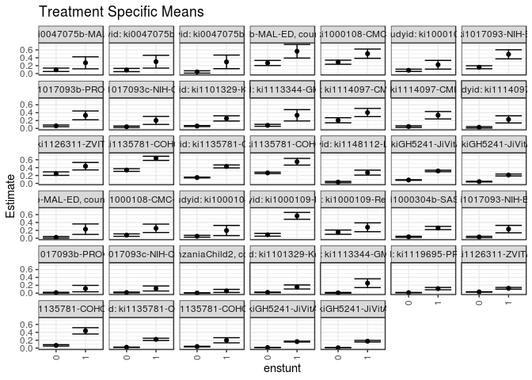

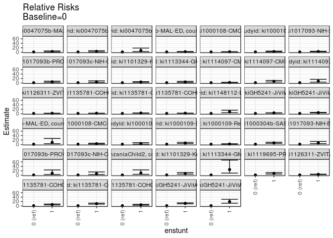

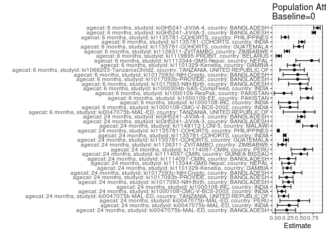

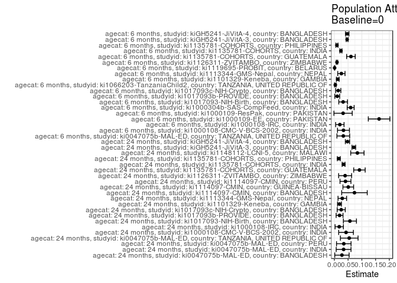

## Results Table

### Parameter: TSM

| agecat | studyid | country | intervention_level | baseline_level | estimate | ci_lower | ci_upper |
| --- | --- | --- | --- | --- | --- | --- | --- |
| 6 months | ki0047075b-MAL-ED | TANZANIA, UNITED REPUBLIC OF | 0 | NA | 0.0240385 | 0.0031807 | 0.0448962 |
| 6 months | ki0047075b-MAL-ED | TANZANIA, UNITED REPUBLIC OF | 1 | NA | 0.2307692 | 0.0982698 | 0.3632687 |
| 6 months | ki1000108-CMC-V-BCS-2002 | INDIA | 0 | NA | 0.0805504 | 0.0493799 | 0.1117209 |
| 6 months | ki1000108-CMC-V-BCS-2002 | INDIA | 1 | NA | 0.2528169 | 0.1458909 | 0.3597429 |
| 6 months | ki1000108-IRC | INDIA | 0 | NA | 0.0511798 | 0.0284652 | 0.0738944 |
| 6 months | ki1000108-IRC | INDIA | 1 | NA | 0.1972398 | 0.0678858 | 0.3265937 |
| 6 months | ki1000109-EE | PAKISTAN | 0 | NA | 0.0898849 | 0.0541229 | 0.1256469 |
| 6 months | ki1000109-EE | PAKISTAN | 1 | NA | 0.5685373 | 0.4809545 | 0.6561202 |
| 6 months | ki1000109-ResPak | PAKISTAN | 0 | NA | 0.1553804 | 0.1013297 | 0.2094312 |
| 6 months | ki1000109-ResPak | PAKISTAN | 1 | NA | 0.2794720 | 0.1666166 | 0.3923275 |
| 6 months | ki1000304b-SAS-CompFeed | INDIA | 0 | NA | 0.0364047 | 0.0219137 | 0.0508958 |
| 6 months | ki1000304b-SAS-CompFeed | INDIA | 1 | NA | 0.2608152 | 0.2214477 | 0.3001826 |
| 6 months | ki1017093-NIH-Birth | BANGLADESH | 0 | NA | 0.0331829 | 0.0167003 | 0.0496655 |
| 6 months | ki1017093-NIH-Birth | BANGLADESH | 1 | NA | 0.2332767 | 0.1389940 | 0.3275594 |
| 6 months | ki1017093b-PROVIDE | BANGLADESH | 0 | NA | 0.0133843 | 0.0035274 | 0.0232413 |
| 6 months | ki1017093b-PROVIDE | BANGLADESH | 1 | NA | 0.1166667 | 0.0353685 | 0.1979649 |
| 6 months | ki1017093c-NIH-Crypto | BANGLADESH | 0 | NA | 0.0178785 | 0.0073753 | 0.0283817 |
| 6 months | ki1017093c-NIH-Crypto | BANGLADESH | 1 | NA | 0.1195145 | 0.0556921 | 0.1833370 |
| 6 months | ki1066203-TanzaniaChild2 | TANZANIA, UNITED REPUBLIC OF | 0 | NA | 0.0058201 | 0.0023899 | 0.0092503 |
| 6 months | ki1066203-TanzaniaChild2 | TANZANIA, UNITED REPUBLIC OF | 1 | NA | 0.0575540 | 0.0188270 | 0.0962809 |
| 6 months | ki1101329-Keneba | GAMBIA | 0 | NA | 0.0210274 | 0.0145527 | 0.0275021 |
| 6 months | ki1101329-Keneba | GAMBIA | 1 | NA | 0.1576052 | 0.1062805 | 0.2089300 |
| 6 months | ki1113344-GMS-Nepal | NEPAL | 0 | NA | 0.0099206 | 0.0012605 | 0.0185807 |
| 6 months | ki1113344-GMS-Nepal | NEPAL | 1 | NA | 0.2542373 | 0.1430313 | 0.3654433 |
| 6 months | ki1119695-PROBIT | BELARUS | 0 | NA | 0.0143807 | 0.0090720 | 0.0196894 |
| 6 months | ki1119695-PROBIT | BELARUS | 1 | NA | 0.1161200 | 0.0860037 | 0.1462363 |
| 6 months | ki1126311-ZVITAMBO | ZIMBABWE | 0 | NA | 0.0320794 | 0.0280799 | 0.0360789 |
| 6 months | ki1126311-ZVITAMBO | ZIMBABWE | 1 | NA | 0.1241798 | 0.1018747 | 0.1464850 |
| 6 months | ki1135781-COHORTS | GUATEMALA | 0 | NA | 0.0686286 | 0.0511568 | 0.0861005 |
| 6 months | ki1135781-COHORTS | GUATEMALA | 1 | NA | 0.4380511 | 0.3573613 | 0.5187408 |
| 6 months | ki1135781-COHORTS | INDIA | 0 | NA | 0.0213699 | 0.0177248 | 0.0250150 |
| 6 months | ki1135781-COHORTS | INDIA | 1 | NA | 0.2220114 | 0.1935603 | 0.2504624 |
| 6 months | ki1135781-COHORTS | PHILIPPINES | 0 | NA | 0.0392999 | 0.0317571 | 0.0468427 |
| 6 months | ki1135781-COHORTS | PHILIPPINES | 1 | NA | 0.1986949 | 0.1337226 | 0.2636672 |
| 6 months | kiGH5241-JiVitA-3 | BANGLADESH | 0 | NA | 0.0141186 | 0.0117360 | 0.0165012 |
| 6 months | kiGH5241-JiVitA-3 | BANGLADESH | 1 | NA | 0.1647576 | 0.1543386 | 0.1751767 |
| 6 months | kiGH5241-JiVitA-4 | BANGLADESH | 0 | NA | 0.0090217 | 0.0052443 | 0.0127991 |
| 6 months | kiGH5241-JiVitA-4 | BANGLADESH | 1 | NA | 0.1751359 | 0.1545055 | 0.1957664 |
| 24 months | ki0047075b-MAL-ED | BANGLADESH | 0 | NA | 0.0949721 | 0.0519217 | 0.1380225 |
| 24 months | ki0047075b-MAL-ED | BANGLADESH | 1 | NA | 0.2727273 | 0.1204165 | 0.4250381 |
| 24 months | ki0047075b-MAL-ED | INDIA | 0 | NA | 0.0896449 | 0.0486534 | 0.1306364 |
| 24 months | ki0047075b-MAL-ED | INDIA | 1 | NA | 0.3005787 | 0.1382555 | 0.4629020 |
| 24 months | ki0047075b-MAL-ED | PERU | 0 | NA | 0.0402299 | 0.0109604 | 0.0694993 |
| 24 months | ki0047075b-MAL-ED | PERU | 1 | NA | 0.2962963 | 0.1236301 | 0.4689625 |
| 24 months | ki0047075b-MAL-ED | TANZANIA, UNITED REPUBLIC OF | 0 | NA | 0.2683077 | 0.2033407 | 0.3332747 |
| 24 months | ki0047075b-MAL-ED | TANZANIA, UNITED REPUBLIC OF | 1 | NA | 0.5657079 | 0.3925735 | 0.7388424 |
| 24 months | ki1000108-CMC-V-BCS-2002 | INDIA | 0 | NA | 0.2880945 | 0.2364712 | 0.3397179 |
| 24 months | ki1000108-CMC-V-BCS-2002 | INDIA | 1 | NA | 0.5041334 | 0.3863884 | 0.6218785 |
| 24 months | ki1000108-IRC | INDIA | 0 | NA | 0.0824648 | 0.0541907 | 0.1107390 |
| 24 months | ki1000108-IRC | INDIA | 1 | NA | 0.2233826 | 0.1126741 | 0.3340912 |
| 24 months | ki1017093-NIH-Birth | BANGLADESH | 0 | NA | 0.1601347 | 0.1218793 | 0.1983901 |
| 24 months | ki1017093-NIH-Birth | BANGLADESH | 1 | NA | 0.4881071 | 0.3722652 | 0.6039490 |
| 24 months | ki1017093b-PROVIDE | BANGLADESH | 0 | NA | 0.0659077 | 0.0445942 | 0.0872211 |
| 24 months | ki1017093b-PROVIDE | BANGLADESH | 1 | NA | 0.3316902 | 0.2198264 | 0.4435540 |
| 24 months | ki1017093c-NIH-Crypto | BANGLADESH | 0 | NA | 0.0430292 | 0.0241417 | 0.0619167 |
| 24 months | ki1017093c-NIH-Crypto | BANGLADESH | 1 | NA | 0.2036847 | 0.1026769 | 0.3046925 |
| 24 months | ki1101329-Keneba | GAMBIA | 0 | NA | 0.0606643 | 0.0487567 | 0.0725719 |
| 24 months | ki1101329-Keneba | GAMBIA | 1 | NA | 0.2547665 | 0.1887142 | 0.3208187 |
| 24 months | ki1113344-GMS-Nepal | NEPAL | 0 | NA | 0.0792587 | 0.0543281 | 0.1041894 |
| 24 months | ki1113344-GMS-Nepal | NEPAL | 1 | NA | 0.3338219 | 0.1893410 | 0.4783029 |
| 24 months | ki1114097-CMIN | BANGLADESH | 0 | NA | 0.2077609 | 0.1430319 | 0.2724900 |
| 24 months | ki1114097-CMIN | BANGLADESH | 1 | NA | 0.4043209 | 0.3001759 | 0.5084660 |
| 24 months | ki1114097-CMIN | GUINEA-BISSAU | 0 | NA | 0.0491663 | 0.0291759 | 0.0691568 |
| 24 months | ki1114097-CMIN | GUINEA-BISSAU | 1 | NA | 0.3360735 | 0.2420236 | 0.4301233 |
| 24 months | ki1114097-CMIN | PERU | 0 | NA | 0.0294213 | 0.0114890 | 0.0473536 |
| 24 months | ki1114097-CMIN | PERU | 1 | NA | 0.2302639 | 0.1390110 | 0.3215167 |
| 24 months | ki1126311-ZVITAMBO | ZIMBABWE | 0 | NA | 0.2474206 | 0.2028929 | 0.2919484 |
| 24 months | ki1126311-ZVITAMBO | ZIMBABWE | 1 | NA | 0.4360872 | 0.3414272 | 0.5307473 |
| 24 months | ki1135781-COHORTS | GUATEMALA | 0 | NA | 0.3383376 | 0.3043420 | 0.3723333 |
| 24 months | ki1135781-COHORTS | GUATEMALA | 1 | NA | 0.6351569 | 0.5827599 | 0.6875539 |
| 24 months | ki1135781-COHORTS | INDIA | 0 | NA | 0.1477402 | 0.1376133 | 0.1578671 |
| 24 months | ki1135781-COHORTS | INDIA | 1 | NA | 0.4299173 | 0.3921789 | 0.4676557 |
| 24 months | ki1135781-COHORTS | PHILIPPINES | 0 | NA | 0.2655866 | 0.2475782 | 0.2835950 |
| 24 months | ki1135781-COHORTS | PHILIPPINES | 1 | NA | 0.5494957 | 0.4639193 | 0.6350721 |
| 24 months | ki1148112-LCNI-5 | MALAWI | 0 | NA | 0.0318971 | 0.0140379 | 0.0497563 |
| 24 months | ki1148112-LCNI-5 | MALAWI | 1 | NA | 0.2725655 | 0.2099304 | 0.3352005 |
| 24 months | kiGH5241-JiVitA-3 | BANGLADESH | 0 | NA | 0.0850726 | 0.0771785 | 0.0929668 |
| 24 months | kiGH5241-JiVitA-3 | BANGLADESH | 1 | NA | 0.3149862 | 0.2959172 | 0.3340552 |
| 24 months | kiGH5241-JiVitA-4 | BANGLADESH | 0 | NA | 0.0441233 | 0.0358132 | 0.0524334 |
| 24 months | kiGH5241-JiVitA-4 | BANGLADESH | 1 | NA | 0.2119479 | 0.1868982 | 0.2369976 |

### Parameter: E(Y)

| agecat | studyid | country | intervention_level | baseline_level | estimate | ci_lower | ci_upper |
| --- | --- | --- | --- | --- | --- | --- | --- |
| 6 months | ki0047075b-MAL-ED | TANZANIA, UNITED REPUBLIC OF | NA | NA | 0.0566802 | 0.0277850 | 0.0855754 |
| 6 months | ki1000108-CMC-V-BCS-2002 | INDIA | NA | NA | 0.1138211 | 0.0813725 | 0.1462698 |
| 6 months | ki1000108-IRC | INDIA | NA | NA | 0.0712531 | 0.0462303 | 0.0962759 |
| 6 months | ki1000109-EE | PAKISTAN | NA | NA | 0.2526882 | 0.2084696 | 0.2969067 |
| 6 months | ki1000109-ResPak | PAKISTAN | NA | NA | 0.1872340 | 0.1372518 | 0.2372162 |
| 6 months | ki1000304b-SAS-CompFeed | INDIA | NA | NA | 0.0958084 | 0.0774939 | 0.1141229 |
| 6 months | ki1017093-NIH-Birth | BANGLADESH | NA | NA | 0.0651769 | 0.0442802 | 0.0860736 |
| 6 months | ki1017093b-PROVIDE | BANGLADESH | NA | NA | 0.0240137 | 0.0115761 | 0.0364514 |
| 6 months | ki1017093c-NIH-Crypto | BANGLADESH | NA | NA | 0.0321678 | 0.0192256 | 0.0451101 |
| 6 months | ki1066203-TanzaniaChild2 | TANZANIA, UNITED REPUBLIC OF | NA | NA | 0.0093642 | 0.0051724 | 0.0135561 |
| 6 months | ki1101329-Keneba | GAMBIA | NA | NA | 0.0335089 | 0.0257898 | 0.0412279 |
| 6 months | ki1113344-GMS-Nepal | NEPAL | NA | NA | 0.0355240 | 0.0202206 | 0.0508273 |
| 6 months | ki1119695-PROBIT | BELARUS | NA | NA | 0.0154178 | 0.0100323 | 0.0208033 |
| 6 months | ki1126311-ZVITAMBO | ZIMBABWE | NA | NA | 0.0417119 | 0.0374091 | 0.0460146 |
| 6 months | ki1135781-COHORTS | GUATEMALA | NA | NA | 0.1290323 | 0.1078261 | 0.1502384 |
| 6 months | ki1135781-COHORTS | INDIA | NA | NA | 0.0453353 | 0.0404119 | 0.0502586 |
| 6 months | ki1135781-COHORTS | PHILIPPINES | NA | NA | 0.0487445 | 0.0406327 | 0.0568562 |
| 6 months | kiGH5241-JiVitA-3 | BANGLADESH | NA | NA | 0.0606746 | 0.0568229 | 0.0645262 |
| 6 months | kiGH5241-JiVitA-4 | BANGLADESH | NA | NA | 0.0558890 | 0.0491390 | 0.0626391 |
| 24 months | ki0047075b-MAL-ED | BANGLADESH | NA | NA | 0.1226415 | 0.0783812 | 0.1669018 |
| 24 months | ki0047075b-MAL-ED | INDIA | NA | NA | 0.1233480 | 0.0804760 | 0.1662200 |
| 24 months | ki0047075b-MAL-ED | PERU | NA | NA | 0.0746269 | 0.0382069 | 0.1110468 |
| 24 months | ki0047075b-MAL-ED | TANZANIA, UNITED REPUBLIC OF | NA | NA | 0.3224299 | 0.2596598 | 0.3852000 |
| 24 months | ki1000108-CMC-V-BCS-2002 | INDIA | NA | NA | 0.3306452 | 0.2827744 | 0.3785159 |
| 24 months | ki1000108-IRC | INDIA | NA | NA | 0.1002445 | 0.0711031 | 0.1293859 |
| 24 months | ki1017093-NIH-Birth | BANGLADESH | NA | NA | 0.2167832 | 0.1777459 | 0.2558205 |
| 24 months | ki1017093b-PROVIDE | BANGLADESH | NA | NA | 0.0849220 | 0.0621566 | 0.1076874 |
| 24 months | ki1017093c-NIH-Crypto | BANGLADESH | NA | NA | 0.0680934 | 0.0462948 | 0.0898920 |
| 24 months | ki1101329-Keneba | GAMBIA | NA | NA | 0.0794203 | 0.0666566 | 0.0921840 |
| 24 months | ki1113344-GMS-Nepal | NEPAL | NA | NA | 0.1082164 | 0.0809323 | 0.1355005 |
| 24 months | ki1114097-CMIN | BANGLADESH | NA | NA | 0.2809917 | 0.2242434 | 0.3377401 |
| 24 months | ki1114097-CMIN | GUINEA-BISSAU | NA | NA | 0.0998185 | 0.0747668 | 0.1248702 |
| 24 months | ki1114097-CMIN | PERU | NA | NA | 0.0699301 | 0.0457690 | 0.0940911 |
| 24 months | ki1126311-ZVITAMBO | ZIMBABWE | NA | NA | 0.2866521 | 0.2451477 | 0.3281565 |
| 24 months | ki1135781-COHORTS | GUATEMALA | NA | NA | 0.4296365 | 0.4000034 | 0.4592696 |
| 24 months | ki1135781-COHORTS | INDIA | NA | NA | 0.1814607 | 0.1711228 | 0.1917985 |
| 24 months | ki1135781-COHORTS | PHILIPPINES | NA | NA | 0.2817996 | 0.2639639 | 0.2996353 |
| 24 months | ki1148112-LCNI-5 | MALAWI | NA | NA | 0.1157168 | 0.0896385 | 0.1417950 |
| 24 months | kiGH5241-JiVitA-3 | BANGLADESH | NA | NA | 0.1559314 | 0.1471744 | 0.1646884 |
| 24 months | kiGH5241-JiVitA-4 | BANGLADESH | NA | NA | 0.0919613 | 0.0825825 | 0.1013401 |

### Parameter: RR

| agecat | studyid | country | intervention_level | baseline_level | estimate | ci_lower | ci_upper |
| --- | --- | --- | --- | --- | --- | --- | --- |
| 6 months | ki0047075b-MAL-ED | TANZANIA, UNITED REPUBLIC OF | 0 | 0 | 1.000000 | 1.000000 | 1.000000 |
| 6 months | ki0047075b-MAL-ED | TANZANIA, UNITED REPUBLIC OF | 1 | 0 | 9.600000 | 3.391639 | 27.172702 |
| 6 months | ki1000108-CMC-V-BCS-2002 | INDIA | 0 | 0 | 1.000000 | 1.000000 | 1.000000 |
| 6 months | ki1000108-CMC-V-BCS-2002 | INDIA | 1 | 0 | 3.138617 | 1.766752 | 5.575723 |
| 6 months | ki1000108-IRC | INDIA | 0 | 0 | 1.000000 | 1.000000 | 1.000000 |
| 6 months | ki1000108-IRC | INDIA | 1 | 0 | 3.853858 | 1.747786 | 8.497734 |
| 6 months | ki1000109-EE | PAKISTAN | 0 | 0 | 1.000000 | 1.000000 | 1.000000 |
| 6 months | ki1000109-EE | PAKISTAN | 1 | 0 | 6.325171 | 4.127146 | 9.693813 |
| 6 months | ki1000109-ResPak | PAKISTAN | 0 | 0 | 1.000000 | 1.000000 | 1.000000 |
| 6 months | ki1000109-ResPak | PAKISTAN | 1 | 0 | 1.798631 | 1.056287 | 3.062685 |
| 6 months | ki1000304b-SAS-CompFeed | INDIA | 0 | 0 | 1.000000 | 1.000000 | 1.000000 |
| 6 months | ki1000304b-SAS-CompFeed | INDIA | 1 | 0 | 7.164318 | 5.102892 | 10.058502 |
| 6 months | ki1017093-NIH-Birth | BANGLADESH | 0 | 0 | 1.000000 | 1.000000 | 1.000000 |
| 6 months | ki1017093-NIH-Birth | BANGLADESH | 1 | 0 | 7.030025 | 3.700480 | 13.355360 |
| 6 months | ki1017093b-PROVIDE | BANGLADESH | 0 | 0 | 1.000000 | 1.000000 | 1.000000 |
| 6 months | ki1017093b-PROVIDE | BANGLADESH | 1 | 0 | 8.716667 | 3.162480 | 24.025537 |
| 6 months | ki1017093c-NIH-Crypto | BANGLADESH | 0 | 0 | 1.000000 | 1.000000 | 1.000000 |
| 6 months | ki1017093c-NIH-Crypto | BANGLADESH | 1 | 0 | 6.684817 | 3.022098 | 14.786675 |
| 6 months | ki1066203-TanzaniaChild2 | TANZANIA, UNITED REPUBLIC OF | 0 | 0 | 1.000000 | 1.000000 | 1.000000 |
| 6 months | ki1066203-TanzaniaChild2 | TANZANIA, UNITED REPUBLIC OF | 1 | 0 | 9.888816 | 4.042664 | 24.189171 |
| 6 months | ki1101329-Keneba | GAMBIA | 0 | 0 | 1.000000 | 1.000000 | 1.000000 |
| 6 months | ki1101329-Keneba | GAMBIA | 1 | 0 | 7.495231 | 4.789627 | 11.729200 |
| 6 months | ki1113344-GMS-Nepal | NEPAL | 0 | 0 | 1.000000 | 1.000000 | 1.000000 |
| 6 months | ki1113344-GMS-Nepal | NEPAL | 1 | 0 | 25.627119 | 9.652859 | 68.036752 |
| 6 months | ki1119695-PROBIT | BELARUS | 0 | 0 | 1.000000 | 1.000000 | 1.000000 |
| 6 months | ki1119695-PROBIT | BELARUS | 1 | 0 | 8.074697 | 5.456263 | 11.949706 |
| 6 months | ki1126311-ZVITAMBO | ZIMBABWE | 0 | 0 | 1.000000 | 1.000000 | 1.000000 |
| 6 months | ki1126311-ZVITAMBO | ZIMBABWE | 1 | 0 | 3.871013 | 3.111175 | 4.816425 |
| 6 months | ki1135781-COHORTS | GUATEMALA | 0 | 0 | 1.000000 | 1.000000 | 1.000000 |
| 6 months | ki1135781-COHORTS | GUATEMALA | 1 | 0 | 6.382919 | 4.665253 | 8.732999 |
| 6 months | ki1135781-COHORTS | INDIA | 0 | 0 | 1.000000 | 1.000000 | 1.000000 |
| 6 months | ki1135781-COHORTS | INDIA | 1 | 0 | 10.388990 | 8.394406 | 12.857506 |
| 6 months | ki1135781-COHORTS | PHILIPPINES | 0 | 0 | 1.000000 | 1.000000 | 1.000000 |
| 6 months | ki1135781-COHORTS | PHILIPPINES | 1 | 0 | 5.055861 | 3.461674 | 7.384212 |
| 6 months | kiGH5241-JiVitA-3 | BANGLADESH | 0 | 0 | 1.000000 | 1.000000 | 1.000000 |
| 6 months | kiGH5241-JiVitA-3 | BANGLADESH | 1 | 0 | 11.669541 | 9.778941 | 13.925659 |
| 6 months | kiGH5241-JiVitA-4 | BANGLADESH | 0 | 0 | 1.000000 | 1.000000 | 1.000000 |
| 6 months | kiGH5241-JiVitA-4 | BANGLADESH | 1 | 0 | 19.412688 | 12.543121 | 30.044550 |
| 24 months | ki0047075b-MAL-ED | BANGLADESH | 0 | 0 | 1.000000 | 1.000000 | 1.000000 |
| 24 months | ki0047075b-MAL-ED | BANGLADESH | 1 | 0 | 2.871658 | 1.398788 | 5.895404 |
| 24 months | ki0047075b-MAL-ED | INDIA | 0 | 0 | 1.000000 | 1.000000 | 1.000000 |
| 24 months | ki0047075b-MAL-ED | INDIA | 1 | 0 | 3.352993 | 1.653129 | 6.800779 |
| 24 months | ki0047075b-MAL-ED | PERU | 0 | 0 | 1.000000 | 1.000000 | 1.000000 |
| 24 months | ki0047075b-MAL-ED | PERU | 1 | 0 | 7.365079 | 2.899635 | 18.707319 |
| 24 months | ki0047075b-MAL-ED | TANZANIA, UNITED REPUBLIC OF | 0 | 0 | 1.000000 | 1.000000 | 1.000000 |
| 24 months | ki0047075b-MAL-ED | TANZANIA, UNITED REPUBLIC OF | 1 | 0 | 2.108430 | 1.428603 | 3.111765 |
| 24 months | ki1000108-CMC-V-BCS-2002 | INDIA | 0 | 0 | 1.000000 | 1.000000 | 1.000000 |
| 24 months | ki1000108-CMC-V-BCS-2002 | INDIA | 1 | 0 | 1.749889 | 1.303989 | 2.348265 |
| 24 months | ki1000108-IRC | INDIA | 0 | 0 | 1.000000 | 1.000000 | 1.000000 |
| 24 months | ki1000108-IRC | INDIA | 1 | 0 | 2.708824 | 1.479527 | 4.959508 |
| 24 months | ki1017093-NIH-Birth | BANGLADESH | 0 | 0 | 1.000000 | 1.000000 | 1.000000 |
| 24 months | ki1017093-NIH-Birth | BANGLADESH | 1 | 0 | 3.048103 | 2.176575 | 4.268603 |
| 24 months | ki1017093b-PROVIDE | BANGLADESH | 0 | 0 | 1.000000 | 1.000000 | 1.000000 |
| 24 months | ki1017093b-PROVIDE | BANGLADESH | 1 | 0 | 5.032650 | 3.143989 | 8.055871 |
| 24 months | ki1017093c-NIH-Crypto | BANGLADESH | 0 | 0 | 1.000000 | 1.000000 | 1.000000 |
| 24 months | ki1017093c-NIH-Crypto | BANGLADESH | 1 | 0 | 4.733640 | 2.437813 | 9.191578 |
| 24 months | ki1101329-Keneba | GAMBIA | 0 | 0 | 1.000000 | 1.000000 | 1.000000 |
| 24 months | ki1101329-Keneba | GAMBIA | 1 | 0 | 4.199608 | 3.034455 | 5.812151 |
| 24 months | ki1113344-GMS-Nepal | NEPAL | 0 | 0 | 1.000000 | 1.000000 | 1.000000 |
| 24 months | ki1113344-GMS-Nepal | NEPAL | 1 | 0 | 4.211799 | 2.464854 | 7.196878 |
| 24 months | ki1114097-CMIN | BANGLADESH | 0 | 0 | 1.000000 | 1.000000 | 1.000000 |
| 24 months | ki1114097-CMIN | BANGLADESH | 1 | 0 | 1.946087 | 1.297606 | 2.918649 |
| 24 months | ki1114097-CMIN | GUINEA-BISSAU | 0 | 0 | 1.000000 | 1.000000 | 1.000000 |
| 24 months | ki1114097-CMIN | GUINEA-BISSAU | 1 | 0 | 6.835442 | 4.169594 | 11.205713 |
| 24 months | ki1114097-CMIN | PERU | 0 | 0 | 1.000000 | 1.000000 | 1.000000 |
| 24 months | ki1114097-CMIN | PERU | 1 | 0 | 7.826433 | 3.779874 | 16.205051 |
| 24 months | ki1126311-ZVITAMBO | ZIMBABWE | 0 | 0 | 1.000000 | 1.000000 | 1.000000 |
| 24 months | ki1126311-ZVITAMBO | ZIMBABWE | 1 | 0 | 1.762534 | 1.334569 | 2.327738 |
| 24 months | ki1135781-COHORTS | GUATEMALA | 0 | 0 | 1.000000 | 1.000000 | 1.000000 |
| 24 months | ki1135781-COHORTS | GUATEMALA | 1 | 0 | 1.877287 | 1.648797 | 2.137441 |
| 24 months | ki1135781-COHORTS | INDIA | 0 | 0 | 1.000000 | 1.000000 | 1.000000 |
| 24 months | ki1135781-COHORTS | INDIA | 1 | 0 | 2.909954 | 2.605028 | 3.250573 |
| 24 months | ki1135781-COHORTS | PHILIPPINES | 0 | 0 | 1.000000 | 1.000000 | 1.000000 |
| 24 months | ki1135781-COHORTS | PHILIPPINES | 1 | 0 | 2.068989 | 1.746408 | 2.451153 |
| 24 months | ki1148112-LCNI-5 | MALAWI | 0 | 0 | 1.000000 | 1.000000 | 1.000000 |
| 24 months | ki1148112-LCNI-5 | MALAWI | 1 | 0 | 8.545148 | 4.661121 | 15.665665 |
| 24 months | kiGH5241-JiVitA-3 | BANGLADESH | 0 | 0 | 1.000000 | 1.000000 | 1.000000 |
| 24 months | kiGH5241-JiVitA-3 | BANGLADESH | 1 | 0 | 3.702556 | 3.326019 | 4.121721 |
| 24 months | kiGH5241-JiVitA-4 | BANGLADESH | 0 | 0 | 1.000000 | 1.000000 | 1.000000 |
| 24 months | kiGH5241-JiVitA-4 | BANGLADESH | 1 | 0 | 4.803535 | 3.836519 | 6.014293 |

### Parameter: PAR

| agecat | studyid | country | intervention_level | baseline_level | estimate | ci_lower | ci_upper |
| --- | --- | --- | --- | --- | --- | --- | --- |
| 6 months | ki0047075b-MAL-ED | TANZANIA, UNITED REPUBLIC OF | 0 | NA | 0.0326417 | 0.0094626 | 0.0558208 |
| 6 months | ki1000108-CMC-V-BCS-2002 | INDIA | 0 | NA | 0.0332707 | 0.0115506 | 0.0549909 |
| 6 months | ki1000108-IRC | INDIA | 0 | NA | 0.0200732 | 0.0047791 | 0.0353674 |
| 6 months | ki1000109-EE | PAKISTAN | 0 | NA | 0.1628033 | 0.1235491 | 0.2020575 |
| 6 months | ki1000109-ResPak | PAKISTAN | 0 | NA | 0.0318536 | -0.0014155 | 0.0651227 |
| 6 months | ki1000304b-SAS-CompFeed | INDIA | 0 | NA | 0.0594036 | 0.0467850 | 0.0720223 |
| 6 months | ki1017093-NIH-Birth | BANGLADESH | 0 | NA | 0.0319940 | 0.0161410 | 0.0478470 |
| 6 months | ki1017093b-PROVIDE | BANGLADESH | 0 | NA | 0.0106294 | 0.0018240 | 0.0194348 |
| 6 months | ki1017093c-NIH-Crypto | BANGLADESH | 0 | NA | 0.0142893 | 0.0048910 | 0.0236877 |
| 6 months | ki1066203-TanzaniaChild2 | TANZANIA, UNITED REPUBLIC OF | 0 | NA | 0.0035441 | 0.0008206 | 0.0062676 |
| 6 months | ki1101329-Keneba | GAMBIA | 0 | NA | 0.0124815 | 0.0074533 | 0.0175096 |
| 6 months | ki1113344-GMS-Nepal | NEPAL | 0 | NA | 0.0256033 | 0.0123778 | 0.0388288 |
| 6 months | ki1119695-PROBIT | BELARUS | 0 | NA | 0.0010371 | 0.0002249 | 0.0018492 |
| 6 months | ki1126311-ZVITAMBO | ZIMBABWE | 0 | NA | 0.0096325 | 0.0072284 | 0.0120366 |
| 6 months | ki1135781-COHORTS | GUATEMALA | 0 | NA | 0.0604036 | 0.0447810 | 0.0760262 |
| 6 months | ki1135781-COHORTS | INDIA | 0 | NA | 0.0239654 | 0.0202174 | 0.0277134 |
| 6 months | ki1135781-COHORTS | PHILIPPINES | 0 | NA | 0.0094445 | 0.0055089 | 0.0133802 |
| 6 months | kiGH5241-JiVitA-3 | BANGLADESH | 0 | NA | 0.0465560 | 0.0431256 | 0.0499863 |
| 6 months | kiGH5241-JiVitA-4 | BANGLADESH | 0 | NA | 0.0468673 | 0.0405831 | 0.0531516 |
| 24 months | ki0047075b-MAL-ED | BANGLADESH | 0 | NA | 0.0276694 | 0.0015425 | 0.0537964 |
| 24 months | ki0047075b-MAL-ED | INDIA | 0 | NA | 0.0337031 | 0.0067630 | 0.0606433 |
| 24 months | ki0047075b-MAL-ED | PERU | 0 | NA | 0.0343970 | 0.0079419 | 0.0608520 |
| 24 months | ki0047075b-MAL-ED | TANZANIA, UNITED REPUBLIC OF | 0 | NA | 0.0541222 | 0.0219609 | 0.0862835 |
| 24 months | ki1000108-CMC-V-BCS-2002 | INDIA | 0 | NA | 0.0425506 | 0.0158175 | 0.0692837 |
| 24 months | ki1000108-IRC | INDIA | 0 | NA | 0.0177797 | 0.0026379 | 0.0329215 |
| 24 months | ki1017093-NIH-Birth | BANGLADESH | 0 | NA | 0.0566485 | 0.0328707 | 0.0804264 |
| 24 months | ki1017093b-PROVIDE | BANGLADESH | 0 | NA | 0.0190143 | 0.0065057 | 0.0315230 |
| 24 months | ki1017093c-NIH-Crypto | BANGLADESH | 0 | NA | 0.0250642 | 0.0103420 | 0.0397864 |
| 24 months | ki1101329-Keneba | GAMBIA | 0 | NA | 0.0187560 | 0.0116619 | 0.0258500 |
| 24 months | ki1113344-GMS-Nepal | NEPAL | 0 | NA | 0.0289577 | 0.0134341 | 0.0444812 |
| 24 months | ki1114097-CMIN | BANGLADESH | 0 | NA | 0.0732308 | 0.0268070 | 0.1196546 |
| 24 months | ki1114097-CMIN | GUINEA-BISSAU | 0 | NA | 0.0506522 | 0.0312336 | 0.0700708 |
| 24 months | ki1114097-CMIN | PERU | 0 | NA | 0.0405088 | 0.0206373 | 0.0603802 |
| 24 months | ki1126311-ZVITAMBO | ZIMBABWE | 0 | NA | 0.0392314 | 0.0156418 | 0.0628211 |
| 24 months | ki1135781-COHORTS | GUATEMALA | 0 | NA | 0.0912989 | 0.0704157 | 0.1121821 |
| 24 months | ki1135781-COHORTS | INDIA | 0 | NA | 0.0337204 | 0.0284507 | 0.0389902 |
| 24 months | ki1135781-COHORTS | PHILIPPINES | 0 | NA | 0.0162130 | 0.0108126 | 0.0216133 |
| 24 months | ki1148112-LCNI-5 | MALAWI | 0 | NA | 0.0838197 | 0.0595570 | 0.1080823 |
| 24 months | kiGH5241-JiVitA-3 | BANGLADESH | 0 | NA | 0.0708588 | 0.0641712 | 0.0775464 |
| 24 months | kiGH5241-JiVitA-4 | BANGLADESH | 0 | NA | 0.0478380 | 0.0400631 | 0.0556129 |

### Parameter: PAF

| agecat | studyid | country | intervention_level | baseline_level | estimate | ci_lower | ci_upper |
| --- | --- | --- | --- | --- | --- | --- | --- |
| 6 months | ki0047075b-MAL-ED | TANZANIA, UNITED REPUBLIC OF | 0 | NA | 0.5758929 | 0.1551277 | 0.7871076 |
| 6 months | ki1000108-CMC-V-BCS-2002 | INDIA | 0 | NA | 0.2923071 | 0.0928380 | 0.4479164 |
| 6 months | ki1000108-IRC | INDIA | 0 | NA | 0.2817177 | 0.0619380 | 0.4500049 |
| 6 months | ki1000109-EE | PAKISTAN | 0 | NA | 0.6442853 | 0.5011485 | 0.7463515 |
| 6 months | ki1000109-ResPak | PAKISTAN | 0 | NA | 0.1701272 | -0.0236075 | 0.3271945 |
| 6 months | ki1000304b-SAS-CompFeed | INDIA | 0 | NA | 0.6200255 | 0.4920449 | 0.7157610 |
| 6 months | ki1017093-NIH-Birth | BANGLADESH | 0 | NA | 0.4908793 | 0.2616294 | 0.6489515 |
| 6 months | ki1017093b-PROVIDE | BANGLADESH | 0 | NA | 0.4426386 | 0.0644328 | 0.6679536 |
| 6 months | ki1017093c-NIH-Crypto | BANGLADESH | 0 | NA | 0.4442117 | 0.1529856 | 0.6353065 |
| 6 months | ki1066203-TanzaniaChild2 | TANZANIA, UNITED REPUBLIC OF | 0 | NA | 0.3784740 | 0.0897894 | 0.5755986 |
| 6 months | ki1101329-Keneba | GAMBIA | 0 | NA | 0.3724823 | 0.2341248 | 0.4858451 |
| 6 months | ki1113344-GMS-Nepal | NEPAL | 0 | NA | 0.7207341 | 0.4071824 | 0.8684428 |
| 6 months | ki1119695-PROBIT | BELARUS | 0 | NA | 0.0672648 | 0.0117531 | 0.1196584 |
| 6 months | ki1126311-ZVITAMBO | ZIMBABWE | 0 | NA | 0.2309284 | 0.1762714 | 0.2819587 |
| 6 months | ki1135781-COHORTS | GUATEMALA | 0 | NA | 0.4681280 | 0.3602074 | 0.5578445 |
| 6 months | ki1135781-COHORTS | INDIA | 0 | NA | 0.5286260 | 0.4636960 | 0.5856950 |
| 6 months | ki1135781-COHORTS | PHILIPPINES | 0 | NA | 0.1937563 | 0.1155655 | 0.2650344 |
| 6 months | kiGH5241-JiVitA-3 | BANGLADESH | 0 | NA | 0.7673060 | 0.7298284 | 0.7995849 |
| 6 months | kiGH5241-JiVitA-4 | BANGLADESH | 0 | NA | 0.8385779 | 0.7623619 | 0.8903498 |
| 24 months | ki0047075b-MAL-ED | BANGLADESH | 0 | NA | 0.2256124 | -0.0032028 | 0.4022383 |
| 24 months | ki0047075b-MAL-ED | INDIA | 0 | NA | 0.2732360 | 0.0402053 | 0.4496886 |
| 24 months | ki0047075b-MAL-ED | PERU | 0 | NA | 0.4609195 | 0.0905879 | 0.6804444 |
| 24 months | ki0047075b-MAL-ED | TANZANIA, UNITED REPUBLIC OF | 0 | NA | 0.1678573 | 0.0627317 | 0.2611918 |
| 24 months | ki1000108-CMC-V-BCS-2002 | INDIA | 0 | NA | 0.1286897 | 0.0443397 | 0.2055947 |
| 24 months | ki1000108-IRC | INDIA | 0 | NA | 0.1773633 | 0.0207681 | 0.3089164 |
| 24 months | ki1017093-NIH-Birth | BANGLADESH | 0 | NA | 0.2613142 | 0.1499186 | 0.3581124 |
| 24 months | ki1017093b-PROVIDE | BANGLADESH | 0 | NA | 0.2239037 | 0.0754446 | 0.3485241 |
| 24 months | ki1017093c-NIH-Crypto | BANGLADESH | 0 | NA | 0.3680856 | 0.1538952 | 0.5280539 |
| 24 months | ki1101329-Keneba | GAMBIA | 0 | NA | 0.2361607 | 0.1494614 | 0.3140223 |
| 24 months | ki1113344-GMS-Nepal | NEPAL | 0 | NA | 0.2675905 | 0.1257298 | 0.3864326 |
| 24 months | ki1114097-CMIN | BANGLADESH | 0 | NA | 0.2606155 | 0.0798507 | 0.4058687 |
| 24 months | ki1114097-CMIN | GUINEA-BISSAU | 0 | NA | 0.5074430 | 0.3287265 | 0.6385789 |
| 24 months | ki1114097-CMIN | PERU | 0 | NA | 0.5792754 | 0.3113809 | 0.7429505 |
| 24 months | ki1126311-ZVITAMBO | ZIMBABWE | 0 | NA | 0.1368608 | 0.0511934 | 0.2147933 |
| 24 months | ki1135781-COHORTS | GUATEMALA | 0 | NA | 0.2125027 | 0.1620120 | 0.2599512 |
| 24 months | ki1135781-COHORTS | INDIA | 0 | NA | 0.1858278 | 0.1575193 | 0.2131851 |
| 24 months | ki1135781-COHORTS | PHILIPPINES | 0 | NA | 0.0575337 | 0.0382641 | 0.0764172 |
| 24 months | ki1148112-LCNI-5 | MALAWI | 0 | NA | 0.7243519 | 0.5441251 | 0.8333274 |
| 24 months | kiGH5241-JiVitA-3 | BANGLADESH | 0 | NA | 0.4544227 | 0.4158899 | 0.4904136 |
| 24 months | kiGH5241-JiVitA-4 | BANGLADESH | 0 | NA | 0.5201968 | 0.4433455 | 0.5864380 |